# Assignment 2- Probability of Default EDA

Marko Konte

6/14/2019

## Paper Reading: Feature engineering strategies for credit card fraud detection.

Analysis of paper:

The paper goes into depth in the benefits of detecting credit card fraud through the aggregation of key features. The authors relied on various versions of Decision Tree’s, Logistic regression, Random Forest, and Bayesian models in order to judge accuracy of detecting credit card fraud. The way this was judged was by using these algorithims against the raw dataset, with aggregated features, and periodic features. The study showed the aggregating features performed better, particularly with the time based aggregations. Instead of taking one transaction at a time, they grouped transactions based on the time of day that they happen.

In order to capture the frequency of transactions not just in one day, the time frames of the periodic breakdown were expanded to 1 week. This was an excellent approach which allowed the model to really identify outliers in unusual transactions done by customer, daily transactions would have shown up consistently 7 times in the period, while weekly transactions would show once. The effectivness of this approach can be expanded to even larger time frames, as customers can have monthly transactions as well that could be outliers. The conclusion of the paper was that aggregated features did, in fact, perform better at predicting fraudulent transactions than raw features with no periodic elements included.

EDA:

```r
library(glmnetUtils)
library(dplyr)
```

```r
library(ggplot2)
library(corrplot)
data <- read.csv('XYZloan_default.csv')

smp_size <- floor(0.50 * nrow(data))

set.seed(123)
train_ind <- sample(seq_len(nrow(data)), size = smp_size)

train <- data[train_ind, ]
test <- data[-train_ind, ]

#Remove rows with majority NA
summary(colSums(is.na(train))/nrow(train))
```

```
##    Min. 1st Qu.  Median    Mean 3rd Qu.    Max.
##  0.0000  0.0053  0.0053  0.1002  0.0053  1.0000
```

```r
train <- train[,-(42:74)]
train <- train[-(29:33)]
```

Sections of features from the dataset:

AP: Application

CD: Call Detail

TD: Credit Center

CR: Credit Bureau

PA: Call Detail

MB: Mobile Info

The above features were seperated in their own objects based on their grouping on the variable level. On each of the sections, added loan_default parameter as well to test the significance of each group of predictors. Below is an example of of AP features and their str and summary information:

```
## 'data.frame':    40000 obs. of  10 variables:
##  $ AP001             : int  30 24 41 46 36 37 46 28 33 41 ...
##  $ AP002             : int  2 1 1 1 2 1 1 1 2 1 ...
##  $ AP003             : int  4 1 1 1 1 1 1 1 1 1 ...
##  $ AP004             : int  12 12 12 12 12 6 12 12 12 12 ...
##  $ AP005             : Factor w/ 55057 levels "3/22/2017 15:12",..: 38201 39413 26427 19791 30581 18538 45444 14232 54548 33269 ...
##  $ AP006             : Factor w/ 4 levels "android","api",..: 4 3 3 3 4 1 3 3 1 1 ...
##  $ AP007             : int  4 5 5 5 5 5 3 5 4 2 ...
##  $ AP008             : int  3 5 4 5 2 5 3 5 5 2 ...
##  $ AP009             : int  0 1 0 1 0 1 1 1 0 1 ...
##  $ train$loan_default: int  0 0 0 0 0 0 0 0 0 1 ...
```

```
##      AP001           AP002           AP003          AP004
##  Min.   :20.00   Min.   :1.000   Min.   :1.00   Min.   : 3.00
##  1st Qu.:26.00   1st Qu.:1.000   1st Qu.:1.00   1st Qu.:12.00
##  Median :30.00   Median :1.000   Median :1.00   Median :12.00
##  Mean   :31.73   Mean   :1.322   Mean   :2.01   Mean   :11.24
##  3rd Qu.:35.00   3rd Qu.:2.000   3rd Qu.:3.00   3rd Qu.:12.00
##  Max.   :56.00   Max.   :2.000   Max.   :6.00   Max.   :12.00
##
##              AP005           AP006           AP007           AP008
##  6/29/2017 15:24:    6   android: 8584   Min.   :1.000   Min.   :1.000
##  6/5/2017 11:19 :    6   api    :  695   1st Qu.:2.000   1st Qu.:2.000
##  4/27/2017 13:30:    5   h5     :22120   Median :3.000   Median :3.000
##  5/12/2017 11:48:    5   ios    : 8601   Mean   :3.312   Mean   :3.125
##  5/16/2017 11:42:    5                   3rd Qu.:5.000   3rd Qu.:4.000
##  5/18/2017 11:22:    5                   Max.   :5.000   Max.   :5.000
##  (Other)        :39968
##      AP009        train$loan_default
##  Min.   :0.0000   Min.   :0.0000
##  1st Qu.:0.0000   1st Qu.:0.0000
##  Median :1.0000   Median :0.0000
##  Mean   :0.7268   Mean   :0.1954
##  3rd Qu.:1.0000   3rd Qu.:0.0000
##  Max.   :1.0000   Max.   :1.0000
##
```

Lead:

The AP features will have a lasso model run with them to identify least significant features tied to loan_default. Since the dataset as a whole has 377 features, it is important to dwindle that down to the significant ones to be used. Once features are identified, will be placed in a new object ‘pabes’.

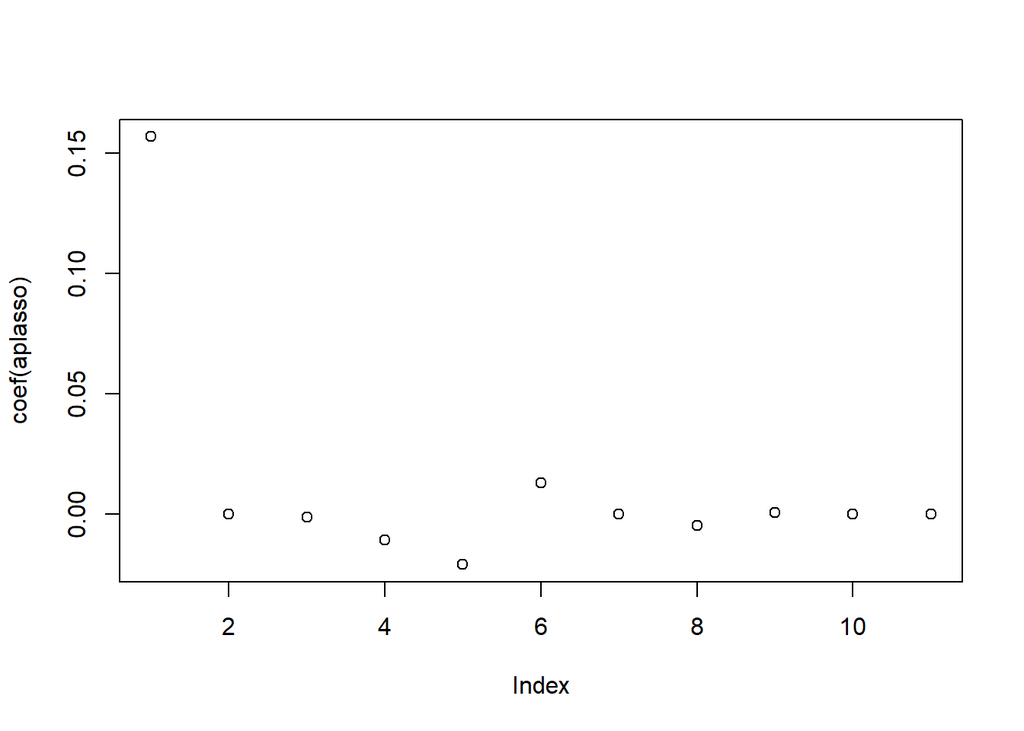

```r
x <- model.matrix(ap$`train$loan_default`~.,data = ap)
y <- ap$`train$loan_default`
aplasso <- cv.glmnet(x,y, alpha = 1)
plot(coef(aplasso))
```

```r
apbest <- as.data.frame((cbind(ap$AP001,ap$AP002,ap$AP003,ap$AP004,ap$AP005,ap$AP006,
                ap$AP007,ap$AP008)))
```

Conclusion:

The lasso was able to identify the features from the Application based variables that have some significance with the metric of loan_default. This grouping of variables were amongs the more significant ones compared to others. This makes sense since things like Age, Education level, and location have correlation with economic situations and therefore with defaulting on loans as well. This parameter will need to be emphasized in the final creation of the model.

Lead:

Next we will run the same lasso model on the two most numerous feature sets to determine if they have any significance with the loan_default feature. These are the grouping of features which add the most ‘noise’ simply because of how many variations of these variables there are.

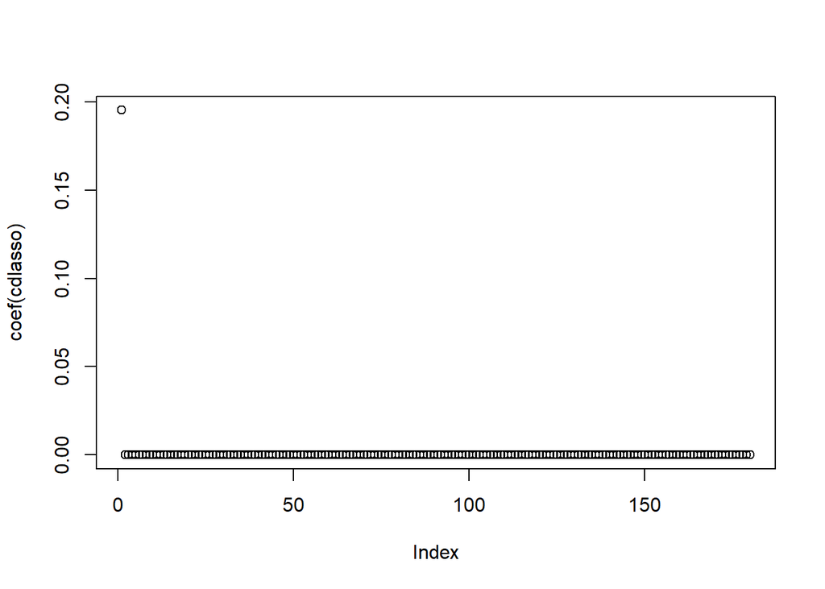

```r
#CD: Call Detail features
x <- model.matrix(cd$`train$loan_default`~.,data = cd)
y <- cd$`train$loan_default`
cdlasso <- cv.glmnet(x,y,alpha=1)
plot(coef(cdlasso))
```

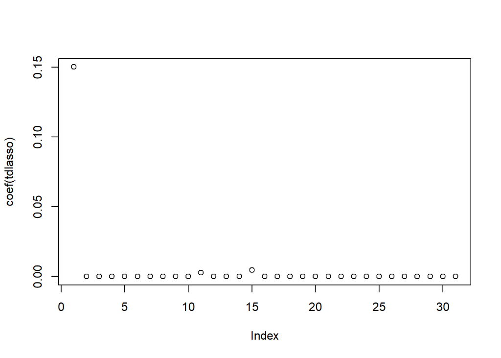

```r
cdbes <- as.data.frame((cbind(cd$CD123)))

#TD: Credit Center
x <- model.matrix(td$`train$loan_default`~., data = td)
y <- td$`train$loan_default`
tdlasso <- cv.glmnet(x,y,alpha=1)
plot(coef(tdlasso))
```

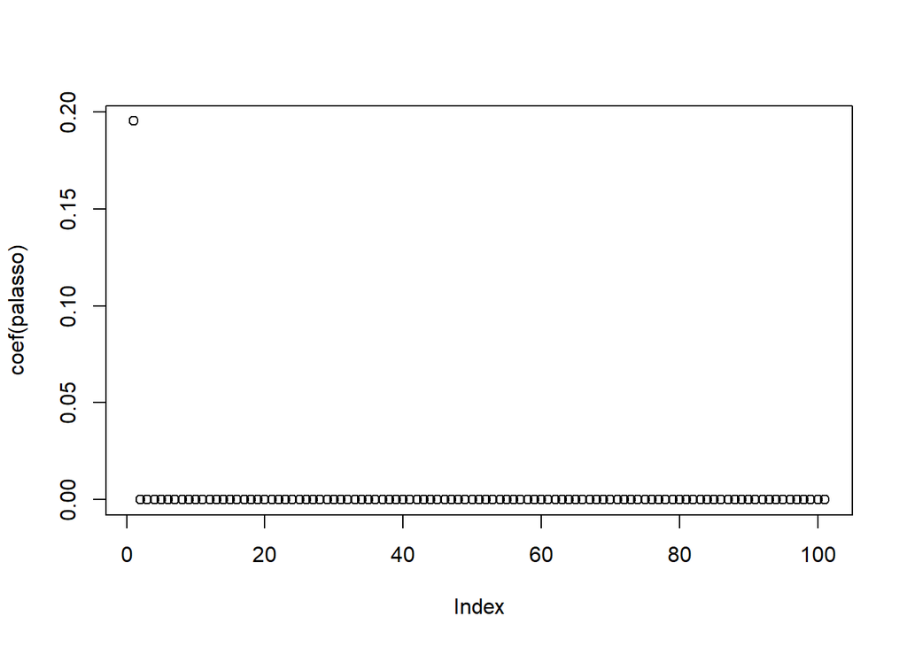

```r
tdbes <- as.data.frame((cbind(td$TD005, td$TD009, td$TD013)))

#PA: Call detail
x <- model.matrix(pa$`train$loan_default`~.,data = pa)
y <- pa$`train$loan_default`
palasso <- cv.glmnet(x,y,alpha=1)
plot(coef(palasso))
```

```r
#No significant features found from this group of variables
```

Conclusion:

Lead:

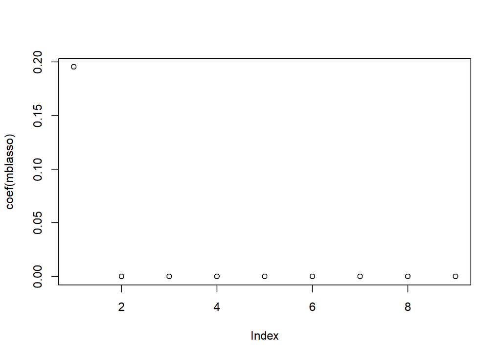

```r
#MB: Mobile Detail
mb$MB007 <- as.numeric(mb$MB007)
x <- model.matrix(mb$`train$loan_default`~., data = mb)
y <- mb$`train$loan_default`
mblasso <- cv.glmnet(x,y,alpha=1)
plot(coef(mblasso))
```

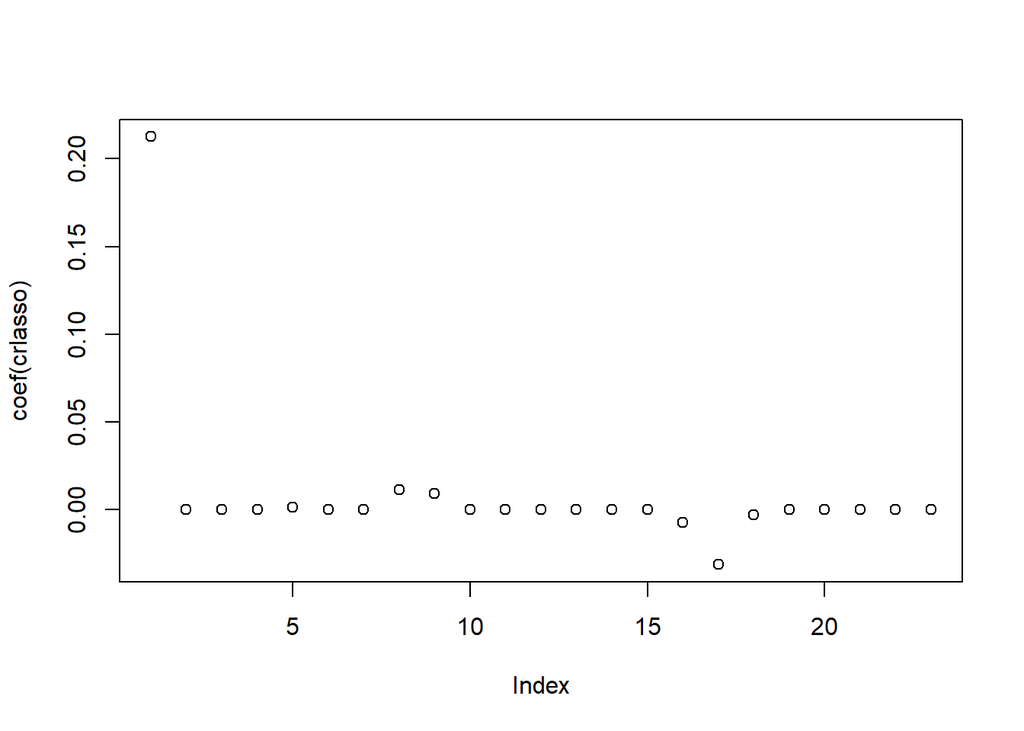

```r
#No significant features found from this group of variables

#CR: Credit Bureau
x <- model.matrix(cr$`train$loan_default`~.,data = cr)
y <- cr$`train$loan_default`

crlasso <- cv.glmnet(x,y,alpha=1)
plot(coef(crlasso))
```

```r
crbes <- as.data.frame(cbind(cr$CR007, cr$CR008, cr$CR015, cr$CR016, cr$CR017,
               cr$CR019))
```

Conclusion:

##Combining the best features identified:

Lead:

We will now combine all the values of the best parameters that were identified and put them in their own dataframe alongside the Loan_Default Variable. In addition, there will be a second dataframe created which will take the application and credit beurea items that were most significant and square them, with the goal being to make those values more significant.

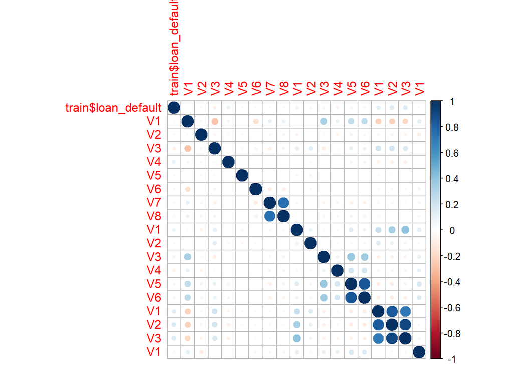

```r
bestft <- cbind(train$loan_default, apbest, crbes, tdbes, cdbes)
corrplot(corr = cor(bestft))
```

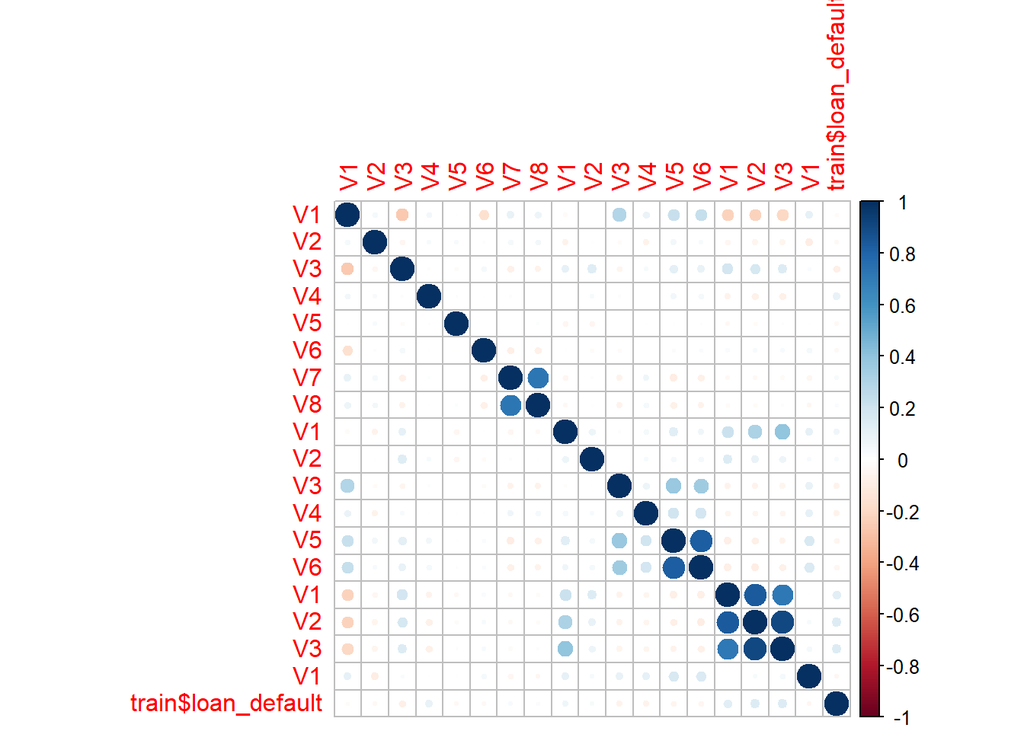

```r
apsq <- apbest^2
crsq <- crbes^2
apcrsq <- cbind(apsq, crsq)

bestft2 <- cbind(apsq, crsq, tdbes, cdbes, train$loan_default)
corrplot(corr = cor(bestft2))
```

Conclusion:

We have come to a collection of variables which can be used to further develop a model for predcting the default risk of clients. The data has identified the most significant variables being that of those related to the applicatoin of a loan (such as age, education, loan term) and Credit Bureau inforamtion (Amount of loan, credit line). Squaring these values did not have a major impact on the correlation with loan amount, but knowing these are the most significant factors will be important in the creation of the final model. In addition, I hope to be able to employ some direct logistic approaches to feature selection as well as employ more robust visualizations to show feature significance.